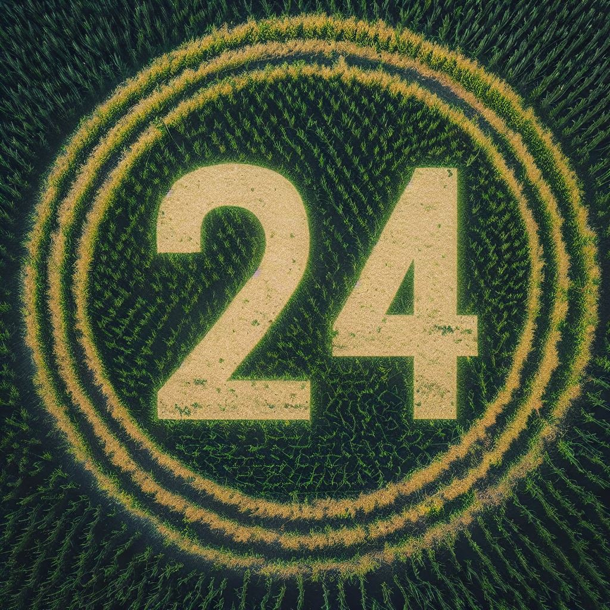

# Projects: Summer 2024

Projects offered for SIPBS Internships, starting Summer 2024.

## 1 Offered Project Summaries

The table below lists PIs who have actively indicated they would welcome SIPBS internship applicants for project work in Summer 2024.

**Important**

All project titles, and their availabilities, are provisional.

**Warning**

Some projects may only go ahead if suitable funding is obtained, or other conditions are met.

| PI | Topics | Project Title |
| --- | --- | --- |
| Dr MA Feeney | Actinobacteria, Streptomyces, Antibiotic, Discovery, Endophytes, Symbiosis | Diversity of Lichen-Associated *Streptomyces* |
| Dr F Murphy | nanotoxicology, in vitro alternative, sustainable cell culture | ‘Humanising’ cell culture conditions for in vitro hazard assessment of nanomaterials |
| Dr K Neves | vascular biology, obesity, pulmonary hypertension | Peripheral vascular effects of pulmonary hypertension (PAH) and obesity |
| Dr Z Rattray |  | Preparation and analysis of nanoparticles |
| Dr N Weir |  | Professionalism, professional identity, and community pharmacy culture: the context of substance dependency **1-2 students** |

## 2 Project Descriptions

### 2.1 Dr F. Murphy: ‘Humanising’ cell culture conditions for in vitro hazard assessment of nanomaterials

Keywords: nanotoxicology, in vitro alternative, sustainable cell culture

#### 2.1.1 Brief overview

This project will involve assessing the impact of replacing animal-derived products (e.g. FBS) with human alternatives in the culture of lung cells to promote more ethical and sustainable toxicity testing of nanomaterials. Cell growth rates, differentiation state and sensitivity to pro-inflammatory agents and exposure to nanomaterials will be compared between cells cultured in media containing common animal-derived supplements or human-derived/synthetic alternatives.

#### 2.1.2 Background

The vast array of nanomaterials (NMs) under development raises ethical concerns over the reliance and extent of animal usage in the hazard assessment of substances. Burden et al. (2017) promoted consideration of the 3Rs (reduce, refine, replace) concept as a framework when developing strategies in nanosafety assessment (Burden et al. 2017). This approach requires the use of New Approach Methods (NAM) and novel in vitro models to generate the appropriate toxicity data for the hazard assessment of new materials.

Many of the methods in current use are reliant on the use of animal-derived materials and reagents, in particular cell-based assays which grow cells in media supplemented with animal serum and the use of monoclonal animals raised in rodents and rabbits. The information gathered by in vitro testing therefore cannot be considered animal-free unless adaptions are made to standard in vitro protocols to replace all animal-derived reagents.

Foetal bovine serum (FBS) is used by default as an additive for cell, organ and tissue culture media in biomedical research and testing to enhance cell growth and proliferation. Serum serves as a source of amino acids, proteins, vitamins, carbohydrates, lipids, hormones, growth factors, inorganic salts, trace elements, and other compounds. It also improves the pH-buffering capacity of the medium and helps to reduce shear stress (i.e., physical damage that is caused by pipette manipulation and stirring). However, the production is unregulated and often associated with ethically and legally questionable practices and animal suffering (van der Valk et al. 2004).

Furthermore using FBS in cell culture presents a number of significant scientific challenges; the exact composition of FBS is unknown, there is a risk of contamination with pathogens, and reproducibility of scientific experiments suffers from inconsistencies between FBS batches (Liu et al. 2023). Omitting ill-defined animal-derived ingredients like FBS is recommended in the Guidance Document on Good In Vitro Method Practices (GIVIMP), a key tool for ensuring reproducible study data generation (OECD 2018).

#### 2.1.3 Objectives:

1. Assess the impact of replacing FBS in human immune cell lines, THP-1 with HPL.
1. Determine growth rate during cell-line maintenance.
2. Assess impact on differentiation from monocyte to macrophage phenotype.
2. The aim of this project is to challenge the status quo methods used as standard in labs, often without consideration of the scientific or ethical implications. Therefore, a strategy to disseminate study aims and results will be developed utilising social media platforms and generation of explainer videos targeted at academics, students and the general public to promote the need to replace animal-derived products in scientific studies.

This project will therefore build the student’s scientific skills in experimental design, lab techniques, analysis of data and dissemination of results.

### 2.2 Dr K. Neves: Peripheral vascular effects of pulmonary hypertension (PAH) and obesity.

Keywords: vascular biology, obesity, pulmonary hypertension

#### 2.2.1 Brief overview

Our aim is to investigate peripheral vascular effects of pulmonary hypertension (PAH) and obesity. To do that, aorta and mesenteric arteries isolated from rats exposed to hypoxia (PAH animal model) and treated for 10 weeks with chow or high fat diet will be investigated. Histological visualization and remodelling of aorta and mesenteric arteries will be assessed by haematoxylin and eosin (H&E) staining. Fibrosis and arterial stiffness will be assessed by picrosirius red and elastin staining, respectively.

### 2.3 Dr N. Weir: Professionalism, professional identity, and community pharmacy culture: the context of substance dependency

#### 2.3.1 Project Team

Natalie Weir, Emma Dunlop, Andrew Radley, Adrian MacKenzie

#### 2.3.2 Project outline

New [Medication Assisted Treatment (MAT) standards](https://www.gov.scot/publications/medication-assisted-treatment-mat-standards-scotland-access-choice-support/), alongside increasing acknowledgment of the importance of Trauma Informed Care (TIC) (Chisholm-Burns and Spivey 2023), will assist community pharmacy to better support people with substance dependency. Little is known about the culture and professionalism that exists within community pharmacy staff in Scotland relating to their role with people with substance dependency, although research indicates the pharmacy setting can be a stigmatising environment which may contribute to health inequalities (Radley et al. 2017). Professional identity, and how it relates to the provision of patient-centred care, is an important consideration for the role of pharmacists whilst the scope of practice is expanding. Students, foundation pharmacists, and newly qualified community pharmacists will be forming their professional identify and can offer unique perspective on the culture and professionalism within this context.

#### 2.3.3 Project aim

To explore the perceptions of the professionalism within community pharmacy culture, in the context of people with substance dependency, through the lens of student and newly qualified pharmacists.

#### 2.3.4 Methods

The internship will follow on from work undertaken by six final year pharmacy students from Sept 2023 until Feb 2024, which will involve exploration of Professionalism (as a factor of how people ‘act’ and ‘think’) and Professional Identity (how they ‘feel’) (Chadha et al. 2022). The internship may involve reviewing literature, undertaking thematic analysis of interview data, writing reports / publications, developing visual research outputs, and/or performing research interviews. You will have close supervision and support throughout.

#### 2.3.5 Output

The findings will offer insight into the existing professionalism and culture within Scottish community pharmacies and the extent to which the MAT standards and TIC principles are currently embedded in practice. Furthermore, the findings will indicate how early experiences in community pharmacy practice influence professional identity with scope to develop training interventions. The results will inform the development of a UK-wide questionnaire with larger cohorts to aid in the exploration and implementation of MAT and TIC principles.

## 3 References

Burden, Natalie, Karin Aschberger, Qasim Chaudhry, et al. 2017. “The 3Rs as a Framework to Support a 21st Century Approach for Nanosafety Assessment.” *Nano Today* 12: 10–13. https://doi.org/10.1016/j.nantod.2016.06.007.

Chadha, Ayush, Theresa L Charrois, and Jill Hall. 2022. “Moving Beyond Professionalism: Pharmacy Students Understanding of Professionalism and Professional Identity.” *Curr. Pharm. Teach. Learn.* 14 (8): 972–81.

Chisholm-Burns, Marie, and Christina Spivey. 2023. “Integration of Trauma-Informed Care into the Doctor of Pharmacy Curriculum.” *Am. J. Pharm. Educ.* 87 (7): 100038.

Liu, Shuai, Wei Yang, Yunlei Li, and Changging Sun. 2023. “Fetal Bovine Serum, an Important Factor Affecting the Reproducibility of Cell Experiments.” *Sci Rep* 13: 1942. https://doi.org/10.1038/s41598-023-29060-7.

OECD. 2018. *Guidance Document on Good in Vitro Method Practices (GIVIMP)*. https://doi.org/10.1787/9789264304796-en.

Radley, Andrew, Karen Melville, Phyllis Easton, Brian Williams, and John F Dillon. 2017. “‘Standing Outside the Junkie Door’—Service Users’ Experiences of Using Community Pharmacies to Access Treatment for Opioid Dependency.” *J. Public Health (Oxf.)* 39 (4): 846–55.

van der Valk, J., D. Mellor, R. Brands, et al. 2004. “The Humane Collection of Fetal Bovine Serum and Possibilities for Serum-Free Cell and Tissue Culture.” *Toxicology in Vitro* 18 (1): 1–12. https://doi.org/10.1016/j.tiv.2003.08.009.

[Twitter](https://twitter.com/scompbiol) [Github](https://github.com/sipbs-compbiol) Email